# Weight lifting - Classifying the quality of the exercise via sensor data

AM

26 July 2022

## Introduction

The final prediction on 20 test samples yields 100% accuracy, if the correlation between window number and activity class detected in the training data holds for the test data as well.

## EDA and tidying

### Missing values

The downloaded data have 160 columns, with 19622 samples for the training data and 20 for the testing. For each sample, the classe variable identifies the mode of execution, 152 variables are measurements records (38 per sensor), and the remaining 7 are identifiers for the user, time and exercise window. The latter variables will therefore be removed. Furthermore, an invalid entry check in the train data reveals 67 measurements columns with 97.93% missing values. A similar check on the test data shows that only 60 columns are not empty. Hence, the empty test columns will be removed from both datasets, obtaining datasets with 53 columns.

### Multicollinearity

```r
library(caret)
cor_mat = cor(new_training[-53])

hc = findCorrelation(cor_mat, cutoff = 0.8)
hc = sort(hc)
reduced_train = new_training[,-c(hc)]
reduced_test = new_testing[,-c(hc)]
red_cols <- dim(reduced_train)[2]
reduced_train$classe <- as.factor(reduced_train$classe)
```

In view of building a prediction model with faster execution and lower variance, a check on multicollinearity is done and the columns having over 0.8 correlation value are removed, leaving only 39 variables. A check for near zero variance confirmed that the reduced dataset has no issues. Finally classe was factorised.

Furthermore, several variables were plotted against classe, and some were evidently showing difference between different classes. As an example, the median of the roll_forearm variable is clearly higher for classe C.

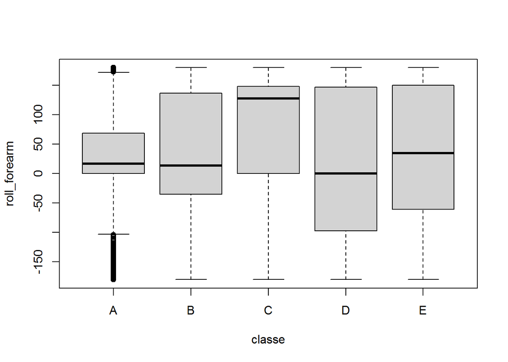

**Fig.1**: *Box and whisker showing the spread of the roll_forearm data across the 5 classes.*

```r
boxplot(reduced_train$roll_forearm ~ reduced_train$classe, xlab = "classe", ylab = "roll_forearm") # C median higher
```

## Model

The model is tested via cross-validation, given the limited number of samples in the test dataset and the requirements for the present assignment. For computational speed reasons, 5-fold cross validation will be performed, together with parallelization when necessary. The performance of the different methods is monitored via the average cross-validation accuracy.

```r
# rpart
set.seed(11111)
library(caret)
cv_rpart_Fit <- train(classe ~.,data = reduced_train, method="rpart",
                      trControl = trainControl(method="cv",number=5))
CM_rpart <- confusionMatrix.train(cv_rpart_Fit)
Acc_rpart <- round(sum(diag(CM_rpart$table)),2)
# lda
fit_LDA <- train(classe ~., method = "lda", data = reduced_train, trControl = trainControl(method="cv",number=5))
CM_LDA <- confusionMatrix.train(fit_LDA)
Acc_lda <- round(sum(diag(CM_LDA$table)),2)
```

**Table 1**: Confusion table for regression with Recursive Partitioning.

| Observed | Observed A | Observed B | Observed C | Observed D | Observed E |
| --- | --- | --- | --- | --- | --- |
| **Predicted** |  |  |  |  |  |
| A | 5091 | 81 | 319 | 86 | 3 |
| B | 1580 | 1286 | 797 | 130 | 4 |
| C | 1585 | 108 | 1384 | 343 | 2 |
| D | 1268 | 568 | 316 | 798 | 266 |
| E | 801 | 675 | 806 | 135 | 1190 |

**Table 2**: Confusion table for regression with Linear Discriminant Analysis.

| Observed | Observed A | Observed B | Observed C | Observed D | Observed E |
| --- | --- | --- | --- | --- | --- |
| **Predicted** |  |  |  |  |  |
| A | 4182 | 507 | 513 | 299 | 79 |
| B | 670 | 2200 | 387 | 249 | 291 |
| C | 365 | 322 | 2201 | 431 | 103 |
| D | 161 | 279 | 405 | 2143 | 228 |
| E | 198 | 647 | 441 | 376 | 1945 |

```r
# gbm booster predictor
library(gbm)
fit_B <- train(classe ~., method = "gbm", data = reduced_train, verbose = FALSE, trControl = trainControl(method="cv",number=5))
CM_B <- confusionMatrix.train(fit_B)
CM_B
```

```
## Cross-Validated (5 fold) Confusion Matrix
##
## (entries are percentual average cell counts across resamples)
##
##           Reference
## Prediction    A    B    C    D    E
##          A 28.0  0.6  0.0  0.0  0.0
##          B  0.3 18.0  0.8  0.1  0.1
##          C  0.1  0.7 16.3  0.7  0.2
##          D  0.1  0.1  0.3 15.4  0.3
##          E  0.0  0.1  0.0  0.2 17.7
##
##  Accuracy (average) : 0.9539
```

```r
Acc_gbm <- round(sum(diag(CM_B$table)),2)
```

```r
#knitr::kable(CM_B, align = 'c', caption = "**Table 3**: Confusion table for regression with gradient Boosting Machine.") %>% kable_styling(full_width = F)
```

Employing a Gradient Boosting Machine (*gbm*) gives an accuracy of 95.39%, which is quite an improvement.

```r
library(parallel)
# Calculate the number of cores for parallel computation
no_cores <- detectCores() - 1
library(doParallel)
# create the cluster for caret to use
cl <- makePSOCKcluster(no_cores)
registerDoParallel(cl)
library(randomForest)
set.seed(11111)
cv_rf_Fit <- train(classe ~.,data = reduced_train, method="rf",
                   trControl = trainControl(method="cv",number=5), allowParallel = TRUE)
stopCluster(cl)
registerDoSEQ()
# Calculate accuracy
CM_rf <- confusionMatrix.train(cv_rf_Fit)
CM_rf
```

```
## Cross-Validated (5 fold) Confusion Matrix
##
## (entries are percentual average cell counts across resamples)
##
##           Reference
## Prediction    A    B    C    D    E
##          A 28.4  0.1  0.0  0.0  0.0
##          B  0.0 19.2  0.1  0.0  0.0
##          C  0.0  0.1 17.2  0.2  0.0
##          D  0.0  0.0  0.1 16.2  0.0
##          E  0.0  0.0  0.0  0.0 18.3
##
##  Accuracy (average) : 0.9932
```

```r
Acc_rf <- round(sum(diag(CM_rf$table)),2)
# Calculate OOB error
CM_count_rf <- cv_rf_Fit$finalModel$confusion
OOB_rf <- round((sum(CM_count_rf)-sum(diag(CM_count_rf)))/sum(CM_count_rf)*100,2)
```

```r
#knitr::kable(CM_rf, align = 'c', caption = "**Table 4**: Confusion table for regression with Random Forest.") %>% kable_styling(full_width = F)
```

Random Forest provides average accuracy from cross validation of 99.32%. Instead of the Out Of Sample error, the Out Of Bag error is estimated, yielding a value of 0.54%. These metrics show that model obtained with random forest method is satisfactory.

## Prediction

```r
predictions <- predict(cv_rf_Fit,newdata = reduced_test)
predictions
```

```
##  [1] B A B A A E D B A A B C B A E E A B B B
## Levels: A B C D E
```

The predicted classe for the samples in the test dataset is the following:

B, A, B, A, A, E, D, B, A, A, B, C, B, A, E, E, A, B, B, B

If actual num_window in test data has the same correspondence to classe as in the training dataset, there is a 100% correct prediction.